# Users Guide

## Introduction

Data on coverage of measles containing vaccines are extracted at calender dates e.g. monthly or quarterly. Thus being cross sectional inventories of measles contaning vaccination coverages.

When more cross sectional coverage-data have been collected, it will be possible to follow coverage over calendar time.

The structural setup is shown in figure 1 and 2, input datasets and variables in appendix 1 and the combined output R data in appendix 2.

Figure 1. Setup

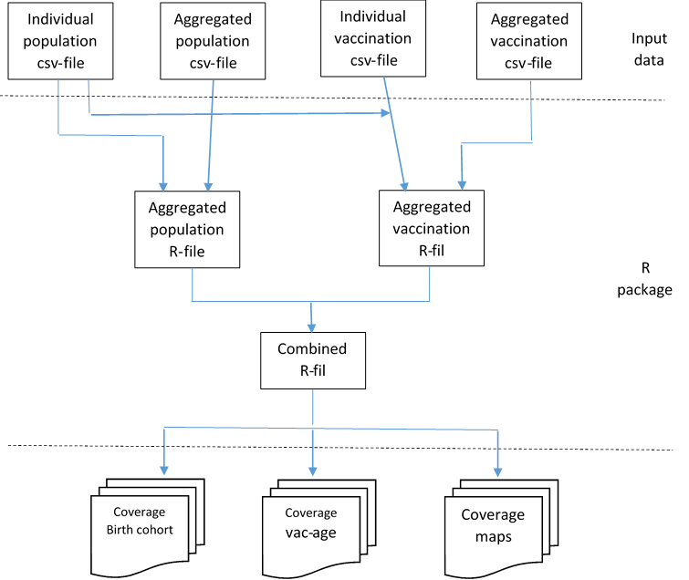

Figure 2. Structure on disk

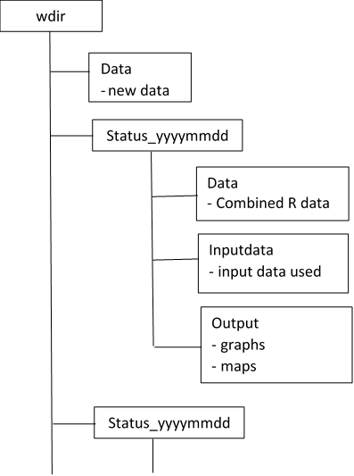

## Input data

Both information on population and vaccinations are needed. Why input data always have to consist of a set of two data-files.

Valid sets of input data will be one of the following:

- Indiviudal population file + Individual vaccination file
- Indiviudal population file + Aggregated vaccination file
- Aggregated population file + Aggregated vaccination file

while the combination Aggregated population file + Individual vaccination file will not be a valid set of input data.

Data in a set of input data should be extracted simultanously or as close in time to one another as possible.  
It is recommend to include date-of-extraction in the naming of the files.

Note:

- The input data csv-files must be semicolon-separated csv-files
- Persons with year of birth < 2005 should not be included in the input data
- For NUTS, minimum NUTS0 i.e. countrycode (two characters), must be included
- NUTS detailing can maximum be level 3
- If NUTS-levels more detailed that NUTS0 are used, then all NUTS must be at the same level – in both input files.

## Scripts

**Initially**, create a dedicated directory for this project (wdir), and a subdirectory in this call data. The later is where input ;-seperated input files must be located

Example:

- Project directory: S:/Data/MCVCovLoc_wdir_DK
- Subdirectory: S:/Data/MCVCovLoc_wdir_DK/data

### New data

For each inventory/status i.e. dates where a valid set of input data are available execute InputData.

Example, with an individual population and an individual vaccination file:

```r
MCVCovLoc::InputData(
  wdir = "S:/Data/MCVCovLoc_wdir_DK",
  StatusDate = "2019-10-01",
  IndividuelPopulationFile = "DKIndPop20191001.csv",
  IndividuelMCVFile = "DKIndVac20191001.csv",
  AggregatedPopulationFile = NA,
  AggregatedMCVFile = NA,
  AdministrativeMCVFile = NA
)
```

- Inputdata – containing the inputdata used
- Data – containing the AggPop, AggVac and combined R files
- Output – containing coverage graphs on NUTS-level 0 for both doses.

### Coverage graphs by Birth cohort

```r
MCVCovLoc::VacCovBd(
  wdir = "S:/Data/MCVCovLoc_wdir_DK",
  StatusDate = "2019-10-01",
  NUTS = "DK01",
  dose = 1,
  save = TRUE
)
```

which creates this graph in the directory wdir/Status_20191001/Output

Do you only want to see the graph, but not store it on disk, use save = FALSE

[figure not shown]

### Coverage graphs by age of vaccination

```r
MCVCovLoc::VacCovAge(
  wdir = "S:/Data/MCVCovLoc_wdir",
  StatusDate = "2019-10-01",
  NUTS = "DK",
  dose = 1,
  save = TRUE
)
```

Which creates this graph in the directory wdir/Status_20191001/Output

Do you only want to see the graph, but not store it on disk, use save = FALSE

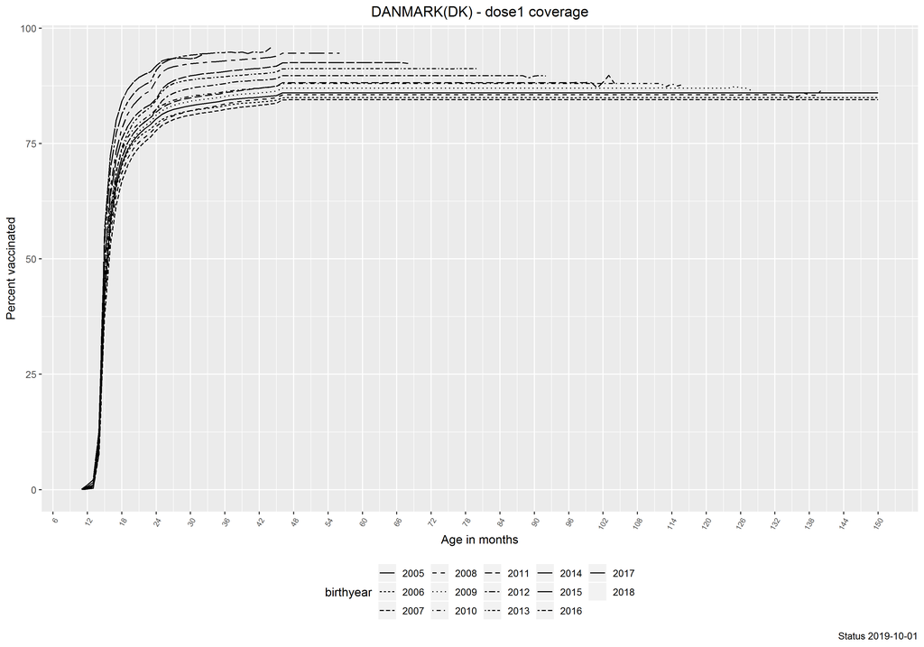

### Coverage maps

A map of the coverage in a birth-cohort may be drawn on different NUTS-levels.

```r
MCVCovLoc::MapCov(
  wdir = 'S:/Data/MCVCovLoc_wdir_DK',
  StatusDate = '2019-12-01',
  BirthCohort = 2005,
  NUTS = 'DK01',
  dose = 2,
  save = TRUE
)
```

Do you only want to see the map, but not store it on disk, use save = FALSE

[figure not shown]

### Shiny dashboard

To have a dashboard showing all your registered data:

```r
MCVCovLoc::ShowCov(
  wdir = "S:/Data/MCVCovLoc_wdir_DK"
)
```

This will start a Shiny daskboard:

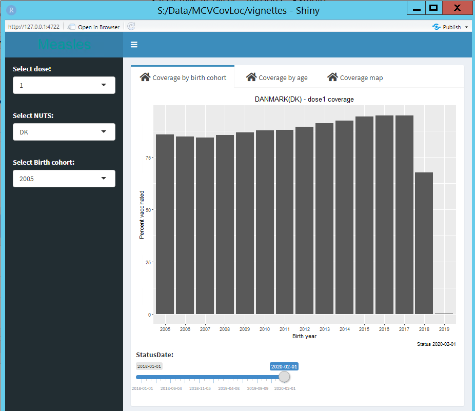

## APPENDIX 1

### Inputdata

Minimal means that these variables must be in the files, with the specified names. There may also be other variables in data e.g. gender, but these are not included in the coverage calculations and output.

**Minimal individual population file**

| Variable name | Meaning | Format |
| --- | --- | --- |
| PersonID | Unique person identifier that allows linking the individual population and individual vaccination files | Character |
| NUTS | NUTS Id for where the person had residence at date of data extraction | Character |
| BirthDate | Date of birth | YYYY-MM-DD |

**Minimal individual vaccination file**

| Variable name | Meaning | Format |
| --- | --- | --- |
| PersonID | Unique person identifier that allows linking the individual population and individual vaccination files | Character |
| VacDate | Date of vaccination | YYYY-MM-DD |
| DoseRecorded | Dose received | 1 – first dose 2 – second dose |

**Minimal aggregated population file**

| Variable name | Meaning | Format |
| --- | --- | --- |
| NUTS | NUTS Id for where the person had residence at date of data extraction | Character |
| BirthYear | Birth cohort | YYYY - Integer(4) |
| Count | Number of persons | Integer |

**Minimal aggregated vaccination file**

| Variable name | Meaning | Format |
| --- | --- | --- |
| NUTS | NUTS Id for where the person had residence at date of data extraction | Character |
| BirthYear | Year of birth | Integer(4) |
| VacAgeMonth | Age in months, when vaccinated | Integer |
| DoseRecorded | Dose received | 1 – first dose 2 – second dose |
| Count | Number of vaccinated persons | Integer |

## APPENDIX 2

**Combined R data**

| Variable name | Meaning | Format |
| --- | --- | --- |
| StatusDate | Date of inventory | YYYY-MM-DD |
| NUTS | NUTS Id for where the person had residence at StatusDate | Character |
| BirthYear | Year of birth | Integer(4) |
| VacAgeMonth | Age in months, when vaccinated | Integer |
| DoseRecorded | Dose received | 1 – first dose 2 – second dose |
| Count | Number of vaccinated persons | Integer |